# Final Project

```r
library(httr)
library(tidyjson)
library(jsonlite)
library(tidyverse)
library(gt)
library(glue)
library(purrr)
library(tidyr)
library(readr)
library(hexbin)
library(ggplot2)
```

# Introduction

My dataset is the [Break Free From Plastic (BFFP)](https://github.com/rfordatascience/tidytuesday/blob/main/data/2021/2021-01-26/readme.mdz) from TidyTuesdays. This dataset looks at plastic waste collected during cleanup events around the world, where volunteers record variables like the country, year, parent company responsible, and counts of different plastic types.

The data comes from Break Free From Plastic global brand audits, which are organized to better understand where plastic pollution is coming from and to hold companies accountable. The dataset I’m using was put together by Sarah Sauve, who combined data from the 2019 and 2020 audits into one dataset. You find it [here](https://github.com/sarahsauve/TidyTuesdays/blob/master/BFFPDashboard/BlogPost.md).

She also created a blog post and a Shiny app describing her data cleaning process and analysis. She made it to contribute to global audit, and as a way to understand plastic waste in St. John.

Each observation represents a summary of plastic collected for a specific company, in a specific country, and year. The values in each row are counts of different types of plastic for each company.

The data was collected to better understand where plastic pollution is coming from and to help hold companies accountable for their plastic waste. We are interested in it because it allows us to identify which companies and countries contribute the most to plastic pollution, and to examine how the composition of plastic types varies across countries and over time.

Here is a snippet of the data set:

```r
plastics <- read.csv("plastics.csv")

head(plastics)
```

```
    country year        parent_company empty hdpe ldpe   o  pet  pp  ps pvc
1 Argentina 2019           Grand Total     0  215   55 607 1376 281 116  18
2 Argentina 2019             Unbranded     0  155   50 532  848 122 114  17
3 Argentina 2019 The Coca-Cola Company     0    0    0   0  222  35   0   0
4 Argentina 2019                 Secco     0    0    0   0   39   4   0   0
5 Argentina 2019            Doble Cola     0    0    0   0   38   0   0   0
6 Argentina 2019                Pritty     0    0    0   0   22   7   0   0
  grand_total num_events volunteers
1        2668          4        243
2        1838          4        243
3         257          4        243
4          43          4        243
5          38          4        243
6          29          4        243
```

Data from both 2019 and 2020 is included. This data was measured through volunteers physically collecting pieces of plastic and recording the type of plastic and company label. The observational unit here is one brand/company audited in one country in one year, described by the following variables:

- **country:** where the brand audit was conducted
- **year:** year of the audit, 2019 or 2020
- **parent company:** The company whose plastic waste was counted. “Unbranded” represents plastic without a known or identifiable brand.
- **empty:** number of unlabeled pieces of plastic
- **hdpe:** number of High-Density Polyethylene pieces
- **ldpe:** number of Low-Density Polyethylene pieces
- **o:** number of “other” types of plastic pieces that don’t fall into the other categories
- **pet:** number of Polyethylene Terephthalate pieces
- **pp:** number of Polypropylene pieces
- **ps:** number of Polystyrene pieces
- **pvc:** number of Polyvinyl Chloride pieces
- **grand total:** the total count of plastic pieces across all types for that country/brand/year audit
- **num_events:** the number of clean-up events held
- **volunteers:** the number of volunteers who participated in the audit

## Data Cleaning

jonthegeek used janitor to clean the data. He…

- used janitor::clean_names() to standardize the column names without changing them manually,
- converted grand_total into a character to deal with the commas that were included in the numbers and then removed the commas,
- used set_names() and map_dfr() to with the .id argument to create the country column,
- dropped duplicate pp and ps columns using select(), and
- added a year column using rbind() to combine the 2019 and 2020 data into one data set.

# Research Question: Do the same big brands keep showing up across countries, and which companies contribute the most plastic pollution?

This summary table shows which companies have the highest plastic pollution score based on recycling difficulty, and I want to see if they overlap with the brands most present across countries. I came up with these weights through an article from the US Department of Energy https://www.energy.gov/sites/default/files/2021-12/ES_ConsumerGuide_RecyclingCodes.pdf

Table 1: shows which companies have the highest plastic pollution score based on recycling difficulty

```r
recycle_weights <- c(pet=1, hdpe=2, pvc=3, o=4, pp=5, ps=6, ldpe=7)

top_companies <- plastics |>
  filter(!parent_company %in% c("Grand Total", "Unbranded", "null", "NULL")) |>
  group_by(parent_company) |>
  summarize(total = sum(grand_total, na.rm = TRUE)) |>
  slice_max(total, n = 10) |>
  pull(parent_company)

plastics |>
  filter(parent_company %in% top_companies) |>
  mutate(pollution_score = pet*1 + hdpe*2 + pvc*3 + o*4 + pp*5 + ps*6 + ldpe*7) |>

  group_by(parent_company) |>
  summarize(
    total_score = sum(pollution_score, na.rm = TRUE),
    total_plastic = sum(grand_total, na.rm = TRUE),
    avg_score_per_piece = total_score / total_plastic) |>
  arrange(desc(total_score)) |>
  gt::gt() |>
  tab_header(
    title = "Plastic Pollution Scores by Company",
    subtitle = "Top 10 companies ranked by weighted recycling difficulty score"
  ) |>
  cols_label(
    parent_company = "Company",
    total_score = "Total Score",
    total_plastic = "Total Plastic",
    avg_score_per_piece = "Avg Score Per Piece"  # make sure this matches exactly
  ) |>
  fmt_number(columns = c(total_score, total_plastic), decimals = 0) |>
  fmt_number(columns = avg_score_per_piece, decimals = 2) |>
  tab_style(
    style = cell_text(weight = "bold"),
    locations = cells_column_labels()) |>
  tab_source_note("Source: Break Free From Plastic brand audit data (2019-2020). Weights based on recycling rates: PET(1), HDPE(2), PVC(3), Other(4), PP(5), PS(6), LDPE(7) from the US Department of Energy")
```

Plastic Pollution Scores by Company

Top 10 companies ranked by weighted recycling difficulty score

| Company | Total Score | Total Plastic | Avg Score Per Piece |
| --- | --- | --- | --- |
| Universal Robina Corporation | 39,708 | 8,651 | 4.59 |
| Nestle | 38,592 | 8,642 | 4.47 |
| Unilever | 37,854 | 8,589 | 4.41 |
| The Coca-Cola Company | 34,010 | 25,530 | 1.33 |
| Colgate-Palmolive | 31,329 | 6,545 | 4.79 |
| La Doo | 15,221 | 15,221 | 1.00 |
| Pepsico | 11,142 | 5,155 | 2.16 |
| Barna | 6,225 | 6,225 | 1.00 |
| Pure Water, Inc. | 2,285 | 5,347 | 0.43 |
| Assorted | 0 | 6,101 | 0.00 |

Source: Break Free From Plastic brand audit data (2019-2020). Weights based on recycling rates: PET(1), HDPE(2), PVC(3), Other(4), PP(5), PS(6), LDPE(7) from the US Department of Energy

Notes: The table ranks the top 10 companies by weighted plastic pollution score, where each plastic type is multiplied by a recycling difficulty weight ranging from 1 (PET, easiest) to 7 (LDPE, hardest) based on EPA recycling rates.

Universal Robina Corporation ranks highest in total score despite having far less plastic than Coca-Cola (8,651 vs 25,530 pieces), meaning their plastic is composed of harder to recycle types. This is reflected in their higher average score per piece of 4.59 compared to Coca-Cola’s 1.33. Assorted has a total score of 0 despite 6,101 pieces, which means none of their plastic fell into a weighted category.

We wanted to see here whether the same big brands kept showing up across countries.

Figure 1: displays the top 15 brands by number of countries they appear in across the 2019–2020 Break Free From Plastic brand audits

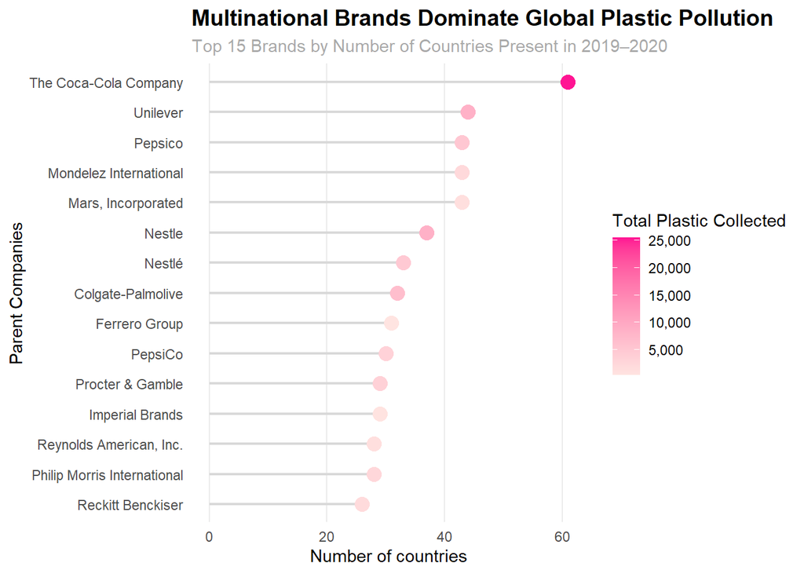

```r
brand_reach <- plastics |>
  filter(!parent_company %in% c("Grand Total", "Unbranded", "null", "NULL")) |>
  group_by(parent_company) |>
  summarise(n_countries = n_distinct(country),
    total_plastic = sum(grand_total, na.rm = TRUE),
    .groups = "drop") |>
  slice_max(n_countries, n = 15) |>
  mutate(parent_company = reorder(parent_company, n_countries))

ggplot(brand_reach, aes(x = n_countries, y = parent_company)) +
  geom_segment(aes(x = 0, xend = n_countries,
                   y = parent_company, yend = parent_company),
               color = "grey85", linewidth = 0.8) +
  geom_point(aes(colour = total_plastic), size = 4) +
  scale_colour_gradient(
    low = "mistyrose", high = "deeppink",
    labels = scales::comma,
    name = "Total Plastic Collected"
  ) +
  labs(
    title = "Multinational Brands Dominate Global Plastic Pollution",
    subtitle = "Top 15 Brands by Number of Countries Present in 2019–2020",
    x = "Number of countries",
    y = "Parent Companies",
    alt = "Lollipop chart showing the top 15 multinational brands by number of countries they appear in across 2019 and 2020 plastic audits. Each horizontal segment extends from zero to the number of countries, with a dot colored by total plastic collected ranging from light pink for lower volume to hot pink for higher volume. The Coca-Cola Company appears in the most countries and has the darkest dot indicating the highest total plastic collected."
  ) +
  theme_minimal() +
  theme(
    plot.title = element_text(face = "bold", size = 14),
    plot.subtitle = element_text(colour = "darkgrey", size = 11),
    panel.grid.minor = element_blank(),
    panel.grid.major.y = element_blank()
  )
```

Notes: The chart displays the top 15 brands by number of countries they appear in across the 2019–2020 Break Free From Plastic brand audits. Each horizontal segment extends from zero to the number of countries that brand was recorded in, and the dot at the end is colored by total plastic collected (light pink indicating lower volume and hot pink indicating higher volume). I filtered out non-company entries such as “Grand Total” and “Unbranded”, then grouping by parent_company and computing both n_distinct(country) and sum(grand_total) using `summarise()`. The Coca-Cola Company stands out clearly as both the most geographically widespread brand and the largest plastic polluter by volume, appearing in over 60 countries with a notably darker dot than all others. Interestingly, several brands like Mondelez International and Mars, Incorporated share a similar country count around 42 but with relatively low plastic volume, suggesting wide reach does not always correspond to high pollution output. Together, the chart confirms that a small set of multinational corporations consistently dominates plastic pollution across the globe.

Here, I wanted see how the proportion of different plastic types differ across countries and changed over time.

Table 2: shows the proportion of each plastic type collected per country for both 2019 and 2020

```r
plastic_types <- c("hdpe", "ldpe", "o", "pet", "pp", "ps", "pvc")

get_proportion <- function(p) {
  plastics |>
    group_by(country, year) |>
    summarize(
      total_plastic = sum(grand_total, na.rm = TRUE),
      type_count = sum(.data[[p]], na.rm = TRUE),
      .groups = "drop") |>
    mutate(
      plastic_type = p,
      proportion = type_count / total_plastic)
}

map_dfr(plastic_types, get_proportion) |>
  select(country, year, total_plastic, plastic_type, proportion) |>
  pivot_wider(names_from = plastic_type, values_from = proportion) |>
  mutate(across(-c(country, year, total_plastic), ~ round(.x, 3))) |>
  pivot_wider(names_from = year,
              values_from = c(hdpe, ldpe, o, pet, pp, ps, pvc, total_plastic),
              names_sep = "_") |>
  filter(!is.na(total_plastic_2019) & !is.na(total_plastic_2020))|>
  slice_head(n = 10) |>
  gt::gt() |>
  tab_header(
    title = "Proportion of Plastic Types by Country and Year",
    subtitle = "Each value represents the share of total plastic for that type"
  ) |>
  tab_spanner(label = "2019", columns = ends_with("_2019")) |>
  tab_spanner(label = "2020", columns = ends_with("_2020")) |>
  cols_label(
    country = "Country",
    hdpe_2019 = "HDPE", ldpe_2019 = "LDPE", o_2019 = "Other",
    pet_2019 = "PET", pp_2019 = "PP", ps_2019 = "PS", pvc_2019 = "PVC",
    total_plastic_2019 = "Total Plastic",
    hdpe_2020 = "HDPE", ldpe_2020 = "LDPE", o_2020 = "Other",
    pet_2020 = "PET", pp_2020 = "PP", ps_2020 = "PS", pvc_2020 = "PVC",
    total_plastic_2020 = "Total Plastic"
  ) |>
  tab_style(
    style = cell_text(weight = "bold"),
    locations = cells_column_labels()
  ) |>
  tab_source_note("Source: Break Free From Plastic brand audit data (2019-2020)") |>
  fmt_number(columns = ends_with("_2019") | ends_with("_2020"), decimals = 2)
```

Proportion of Plastic Types by Country and Year

Each value represents the share of total plastic for that type

| Country | 2019 HDPE | 2019 LDPE | 2019 Other | 2019 PET | 2019 PP | 2019 PS | 2019 PVC | 2019 Total Plastic | 2020 HDPE | 2020 LDPE | 2020 Other | 2020 PET | 2020 PP | 2020 PS | 2020 PVC | 2020 Total Plastic |
| --- | --- | --- | --- | --- | --- | --- | --- | --- | --- | --- | --- | --- | --- | --- | --- | --- |
| Argentina | 0.08 | 0.02 | 0.23 | 0.52 | 0.10 | 0.04 | 0.01 | 5,336.00 | 0.12 | 0.13 | 0.20 | 0.13 | 0.24 | 0.06 | 0.00 | 1,086.00 |
| Australia | 0.00 | 0.00 | 0.00 | 1.00 | 0.00 | 0.00 | 0.00 | 6.00 | 0.02 | 0.13 | 0.54 | 0.08 | 0.22 | 0.00 | 0.00 | 1,668.00 |
| Bangladesh | 0.00 | 0.00 | 1.00 | 0.00 | 0.00 | 0.00 | 0.00 | 32.00 | 0.16 | 0.00 | 0.65 | 0.12 | 0.04 | 0.02 | 0.00 | 2,383.00 |
| Benin | 0.00 | 0.00 | 0.00 | 1.00 | 0.00 | 0.00 | 0.00 | 9,976.00 | 0.00 | 0.00 | 0.00 | 1.00 | 0.00 | 0.00 | 0.00 | 342.00 |
| Brazil | 0.01 | 0.00 | 0.76 | 0.05 | 0.19 | 0.00 | 0.00 | 9,468.00 | 0.05 | 0.25 | 0.17 | 0.18 | 0.24 | 0.09 | 0.01 | 2,257.00 |
| Bulgaria | 0.00 | 0.00 | 0.00 | 1.00 | 0.00 | 0.00 | 0.00 | 16.00 | 0.02 | 0.07 | 0.26 | 0.15 | 0.41 | 0.03 | 0.03 | 480.00 |
| Burkina Faso | 0.00 | 0.36 | 0.05 | 0.56 | 0.02 | 0.01 | 0.00 | 11,636.00 | 0.03 | 0.00 | 0.41 | 0.53 | 0.01 | 0.01 | 0.00 | 8,774.00 |
| Canada | 0.00 | 0.00 | 1.00 | 0.00 | 0.00 | 0.00 | 0.00 | 2.00 | 0.06 | 0.32 | 0.23 | 0.15 | 0.15 | 0.08 | 0.00 | 1,887.00 |
| China | 0.00 | 0.00 | 0.66 | 0.34 | 0.00 | 0.00 | 0.00 | 6,918.00 | 0.00 | 0.00 | 0.94 | 0.05 | 0.00 | 0.00 | 0.00 | 2,332.00 |
| Colombia | 0.00 | 0.00 | 1.00 | 0.00 | 0.00 | 0.00 | 0.00 | 1,712.00 | 0.06 | 0.07 | 0.26 | 0.57 | 0.04 | 0.00 | 0.00 | 6,215.00 |

Source: Break Free From Plastic brand audit data (2019-2020)

Notes: The table shows the proportion of each plastic type collected per country for both 2019 and 2020, where each value represents that plastic type’s share of the country’s total plastic. PET dominates in many countries like Benin (1.00 in both years) meaning all their collected plastic was PET. Some countries show notable shifts between years, for example Australia went from 100% PET in 2019 to a more diverse mix in 2020. Bangladesh had 100% Other plastic in 2019 but shifted toward Other and HDPE in 2020.

Here, I wanted see how the proportion of different plastic types differ across countries and changed over time through a bar chart.

Figure 2: shows the proportion of each plastic type collected across the top 5 countries in 2019 and 2020

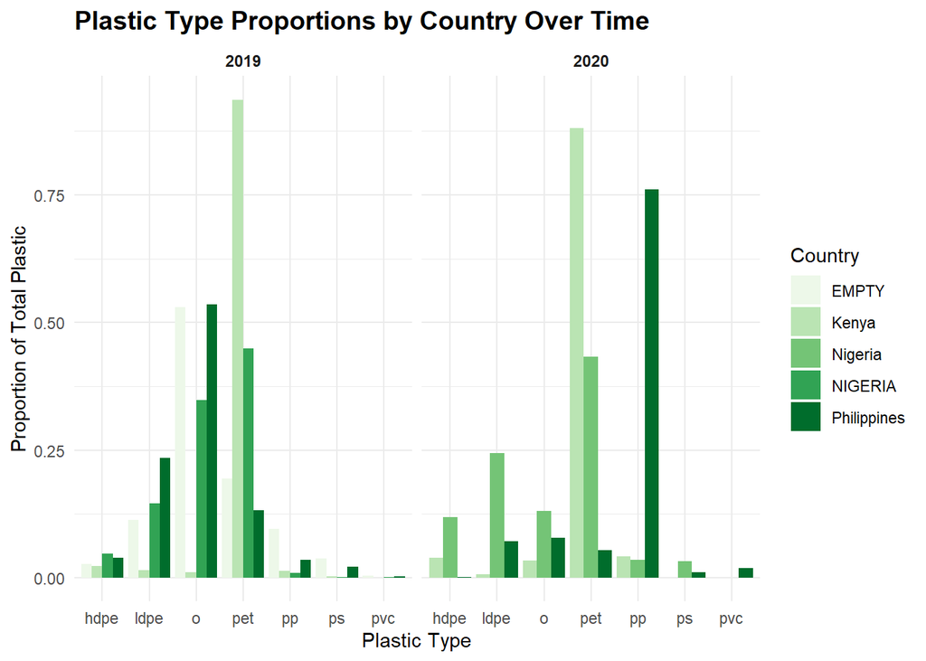

```r
top_countries <- plastics |>
  filter(!parent_company %in% c("Grand Total", "Unbranded", "null", "NULL")) |>
  group_by(country) |>
  summarize(total = sum(grand_total, na.rm = TRUE)) |>
  slice_max(total, n = 5) |>
  pull(country)

map_dfr(plastic_types, get_proportion) |>
  filter(country %in% top_countries) |>
  ggplot(aes(x = plastic_type, y = proportion, fill = country)) +
  geom_col(position = "dodge") +
  facet_wrap(~ year) +
  labs(
    title = "Plastic Type Proportions by Country Over Time",
    x = "Plastic Type",
    y = "Proportion of Total Plastic",
    fill = "Country",
    alt = "Faceted bar chart showing the proportion of each plastic type collected in the top 5 polluting countries in 2019 and 2020. PET dominates across most countries and both years. Each country is represented by a different color. The chart is split into two panels, one for 2019 and one for 2020, allowing us to compare plastic type distributions over time."
  ) +
  scale_fill_brewer(palette = "wesanderson") +
  theme_minimal() +
  theme(
    plot.title = element_text(face = "bold", size = 14),
    strip.text = element_text(face = "bold")
  )
```

# Research Question 2: Is plastic waste associated with air quality across countries?

## New data: [Country Capitals](https://www.kaggle.com/datasets/nikitagrec/world-capitals-gps?resource=download)

**Description:** The Country Capitals dataset was published on Kaggle by Nikita Grec and contains geographical information for countries and their capital cities worldwide. We do not know exactly how or when the data was originally collected, but it is publicly available on Kaggle.

Each observation in the dataset represents a country, including the country name, country code, capital city name, and the latitude and longitude coordinates of that capital. The data covers countries worldwide, making it a complete geographic reference dataset.

We used this dataset to connect our plastic pollution data and the Air Quality API. Since the API requires geographic coordinates as input, we joined the capital city coordinates to our plastics dataset by country name, allowing us to pull air quality measurements for each country in our analysis.

Here’s a snippet of the data set:

```r
country_data <- read_csv("concap.csv")
head(country_data)
```

```
# A tibble: 6 × 6
  CountryName           CapitalName CapitalLatitude CapitalLongitude CountryCode
  <chr>                 <chr>                 <dbl>            <dbl> <chr>
1 Somaliland            Hargeisa              9.55              44.0 NULL
2 South Georgia and So… King Edwar…         -54.3              -36.5 GS
3 French Southern and … Port-aux-F…         -49.4               70.2 TF
4 Palestine             Jerusalem            31.8               35.2 PS
5 Aland Islands         Mariehamn            60.1               19.9 AX
6 Nauru                 Yaren                -0.548            167.  NR
# ℹ 1 more variable: ContinentName <chr>
```

Below, we remove the unnecessary columns, keeping the country, capital, and coordinates columns, and then combine the new data with our existing Plastic Waste data set.

```r
capitals <- country_data |>
  select(c(1:4)) |>
  rename("country" = "CountryName",
         "capital_city" = "CapitalName",
         "capital_lat" = "CapitalLatitude",
         "capital_long" = "CapitalLongitude"
         )

pollution_data <- left_join(plastics, capitals, by = "country")
```

## New Data: [Air Quality API](https://api-ninjas.com/api/airquality)

**Description:** The air quality data was provided by API Ninjas, a platform that collects real-time environmental data from monitoring sources around the world. We do not know exactly which monitoring sources they come from, but the data is publicly accessible through their API endpoint.

The data was collected at the country level using the capital city coordinates from our Country Capitals dataset as location inputs. This means each observation represents the air quality at a country’s capital city rather than the country as a whole.

The data was pulled in 2026. We collected it by sending HTTP requests to the API Ninjas Air Quality endpoint with latitude and longitude coordinates as inputs. For each location the API returned measurements for several pollutants including CO, NO2, O3, PM2.5, PM10, and SO2 as well as an overall Air Quality Index (AQI) score, where a higher AQI indicates worse air quality.

We chose this data because it allows us to explore whether countries with more plastic pollution also tend to have worse air quality. By combining this with our plastic audit dataset we can investigate whether plastic pollution is connected to broader environmental issues at the country level.

```r
# read in air_data
air_data <- read_csv(file = "air_data.csv")
# combine
pollution_data <- left_join(pollution_data, air_data, by = "country")
head(pollution_data)
```

```
    country year        parent_company empty hdpe ldpe   o  pet  pp  ps pvc
1 Argentina 2019           Grand Total     0  215   55 607 1376 281 116  18
2 Argentina 2019             Unbranded     0  155   50 532  848 122 114  17
3 Argentina 2019 The Coca-Cola Company     0    0    0   0  222  35   0   0
4 Argentina 2019                 Secco     0    0    0   0   39   4   0   0
5 Argentina 2019            Doble Cola     0    0    0   0   38   0   0   0
6 Argentina 2019                Pritty     0    0    0   0   22   7   0   0
  grand_total num_events volunteers capital_city capital_lat capital_long
1        2668          4        243 Buenos Aires   -34.58333    -58.66667
2        1838          4        243 Buenos Aires   -34.58333    -58.66667
3         257          4        243 Buenos Aires   -34.58333    -58.66667
4          43          4        243 Buenos Aires   -34.58333    -58.66667
5          38          4        243 Buenos Aires   -34.58333    -58.66667
6          29          4        243 Buenos Aires   -34.58333    -58.66667
  CO_concentration CO_aqi NO2_concentration NO2_aqi O3_concentration O3_aqi
```

[output cut: 20 more lines]

```r
air_vs_plastic <- pollution_data |>
  filter(!parent_company %in% c("Grand Total", "Unbranded", "null", "NULL")) |>
  group_by(country) |>
  summarize(
    total_plastic = sum(grand_total, na.rm = TRUE),
    total_volunteers = sum(volunteers, na.rm = TRUE),
    avg_aqi = mean(overall_aqi, na.rm = TRUE)) |>
  filter(!is.na(avg_aqi), total_plastic > 0) |>
  arrange(desc(total_plastic))

air_vs_plastic |>
  slice_max(total_plastic, n = 10)
```

```
# A tibble: 10 × 4
   country      total_plastic total_volunteers avg_aqi
   <chr>                <int>            <int>   <dbl>
 1 Philippines          58094          2767429     195
 2 Nigeria              21834           698967      22
 3 Kenya                14522           184128      24
 4 India                14478           140354     129
 5 Indonesia            12843          4457364      42
 6 Vietnam               9007           273802     100
 7 Cameroon              8253            58050       5
 8 Burkina Faso          7583             8229      84
 9 Ukraine               7383           126042     116
10 China                 5791          1363419     219
```

Figure 3: bubble plot shows the relationship between total plastic waste and average Air Quality Index (AQI) for each country

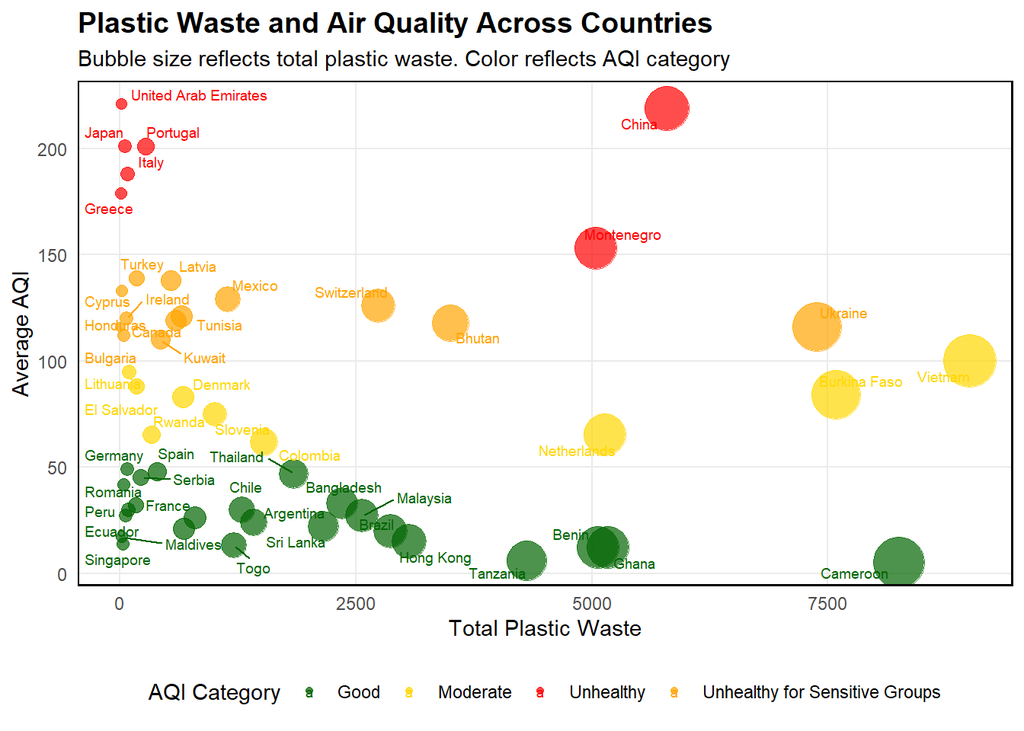

```r
Q1 <- quantile(air_vs_plastic$total_plastic, 0.25)
Q3 <- quantile(air_vs_plastic$total_plastic, 0.75)
IQR <- Q3 - Q1

air_vs_plastic_clean <- air_vs_plastic |>
  filter(
    total_plastic >= Q1 - 1.5 * IQR,
    total_plastic <= Q3 + 1.5 * IQR
  )

air_vs_plastic_clean |>
  mutate(aqi_category = case_when(
    avg_aqi <= 50  ~ "Good",
    avg_aqi <= 100 ~ "Moderate",
    avg_aqi <= 150 ~ "Unhealthy for Sensitive Groups",
    TRUE           ~ "Unhealthy"
  )) |>
  ggplot(aes(x = total_plastic, y = avg_aqi, size = total_plastic, color = aqi_category)) +
  geom_point(alpha = 0.7) +
  ggrepel::geom_text_repel(
    aes(label = country),
    size = 2.5,
    max.overlaps = 10
  ) +
  scale_size_continuous(range = c(2, 12)) +
  scale_color_manual(values = c(
    "Good" = "darkgreen",
    "Moderate" = "gold",
    "Unhealthy for Sensitive Groups" = "orange",
    "Unhealthy" = "red"
  )) +
  labs(
    title = "Plastic Waste and Air Quality Across Countries",
    subtitle = "Bubble size reflects total plastic waste. Color reflects AQI category",
    x = "Total Plastic Waste",
    y = "Average AQI",
    color = "AQI Category",
    alt = "Bubble plot where each bubble is a country. Bubble size represents total plastic waste and color represents air quality category."
  ) +
  theme_minimal() +
  theme(
    text = element_text(family = "Arial"),
    plot.title = element_text(face = "bold", size = 14),
    plot.subtitle = element_text(size = 11),
    panel.border = element_rect(color = "black", fill = NA, linewidth = 0.8),
    panel.grid.minor = element_blank(),
    legend.position = "bottom"
  ) +
  guides(size = "none")
```

Notes: This bubble plot shows the relationship between total plastic waste and average Air Quality Index (AQI) for each country. Each bubble is one country, with bubble size representing how much plastic waste was collected and color showing the air quality category. Most countries are clustered in the bottom left, meaning they have relatively low plastic waste and moderate air quality. Countries with poor air quality appear across all levels of plastic waste, not just the high end, which suggests that plastic waste alone does not determine a country’s air quality. A few labeled countries stand out as having surprisingly bad air quality despite low plastic waste totals, pointing to other factors at play. Overall, the plot shows that the relationship between plastic waste and air quality is weak and inconsistent across countries.

Table 3: groups countries into four quartiles based on their total plastic waste, from lowest (Q1) to highest (Q4)

```r
air_vs_plastic_clean |>
  mutate(
    plastic_quartile = case_when(
      total_plastic <= quantile(total_plastic, 0.25) ~ "Low (Q1)",
      total_plastic <= quantile(total_plastic, 0.50) ~ "Medium-Low (Q2)",
      total_plastic <= quantile(total_plastic, 0.75) ~ "Medium-High (Q3)",
      TRUE                                           ~ "High (Q4)"
    ),
    plastic_quartile = factor(plastic_quartile, levels = c("Low (Q1)", "Medium-Low (Q2)", "Medium-High (Q3)", "High (Q4)"))
  ) |>
  group_by(plastic_quartile) |>
  summarise(
    n_countries = n(),
    avg_aqi = round(mean(avg_aqi, na.rm = TRUE), 2),
    min_aqi = round(min(avg_aqi, na.rm = TRUE), 2),
    max_aqi = round(max(avg_aqi, na.rm = TRUE), 2)
  ) |>
  gt() |>
  opt_table_font(font = "Arial") |>
  tab_header(
    title = "Air Quality by Plastic Waste Level",
    subtitle = "Countries grouped into quartiles by total plastic waste"
  ) |>
  cols_label(
    plastic_quartile = "Plastic Waste Group",
    n_countries = "Number of Countries",
    avg_aqi = "Average AQI",
    min_aqi = "Minimum AQI",
    max_aqi = "Maximum AQI"
  ) |>
  tab_style(
    style = cell_text(weight = "bold"),
    locations = cells_column_labels()
  ) |>
  data_color(
    columns = avg_aqi,
    colors = scales::col_numeric(
      palette = c("darkgreen", "yellow", "red"),
      domain = NULL
    )
  ) |>
  tab_source_note("Note: Higher AQI indicates worse air quality. Countries filtered to remove outliers.")
```

Air Quality by Plastic Waste Level

Countries grouped into quartiles by total plastic waste

| Plastic Waste Group | Number of Countries | Average AQI | Minimum AQI | Maximum AQI |
| --- | --- | --- | --- | --- |
| Low (Q1) | 14 | 103.50 | 103.50 | 103.50 |
| Medium-Low (Q2) | 13 | 98.77 | 98.77 | 98.77 |
| Medium-High (Q3) | 13 | 48.85 | 48.85 | 48.85 |
| High (Q4) | 13 | 71.15 | 71.15 | 71.15 |

Note: Higher AQI indicates worse air quality. Countries filtered to remove outliers.

Table 4: compares the 5 countries with the best air quality against the 5 countries with the worst air quality

```r
top_aqi <- air_vs_plastic_clean |>
  arrange(desc(avg_aqi)) |>
  head(5) |>
  mutate(group = "Worst Air Quality")

bottom_aqi <- air_vs_plastic_clean |>
  arrange(avg_aqi) |>
  head(5) |>
  mutate(group = "Best Air Quality")

bind_rows(top_aqi, bottom_aqi) |>
  select(group, country, avg_aqi, total_plastic) |>
  gt(groupname_col = "group") |>
  opt_table_font(font = "Arial") |>
  tab_header(
    title = "Best vs Worst Air Quality Countries",
    subtitle = "Do countries with the worst air quality also have the most plastic waste?"
  ) |>
  cols_label(
    country = "Country",
    avg_aqi = "Average AQI",
    total_plastic = "Total Plastic Waste"
  ) |>
  tab_style(
    style = cell_text(weight = "bold"),
    locations = cells_column_labels()
  ) |>
  tab_style(
    style = cell_text(weight = "bold", color = "red"),
    locations = cells_row_groups()
  ) |>
  fmt_number(columns = c(avg_aqi, total_plastic), decimals = 2) |>
  tab_source_note("Note: Top and bottom 5 countries ranked by average AQI across 2019-2020.")
```

Best vs Worst Air Quality Countries

Do countries with the worst air quality also have the most plastic waste?

| Country | Average AQI | Total Plastic Waste |
| --- | --- | --- |
| Worst Air Quality |  |  |
| United Arab Emirates | 221.00 | 12.00 |
| China | 219.00 | 5,791.00 |
| Portugal | 201.00 | 272.00 |
| Japan | 201.00 | 53.00 |
| Italy | 188.00 | 82.00 |
| Best Air Quality |  |  |
| Cameroon | 5.00 | 8,253.00 |
| Tanzania | 6.00 | 4,308.00 |
| Ghana | 12.00 | 5,169.00 |
| Benin | 12.00 | 5,066.00 |
| Togo | 13.00 | 1,209.00 |

Note: Top and bottom 5 countries ranked by average AQI across 2019-2020.

Notes: This table compares the 5 countries with the best air quality against the 5 countries with the worst air quality, showing how much plastic waste each country produced. If plastic waste and air quality were strongly linked, we would expect the worst air quality countries to also have the highest plastic waste totals. Looking across both groups, if the plastic waste numbers are similar or inconsistent between the two groups, it suggests that other factors beyond plastic waste are driving air quality differences between countries.

## Statistical Model

Figure 4: scatter plot shows the relationship between total plastic waste and average AQI for each country

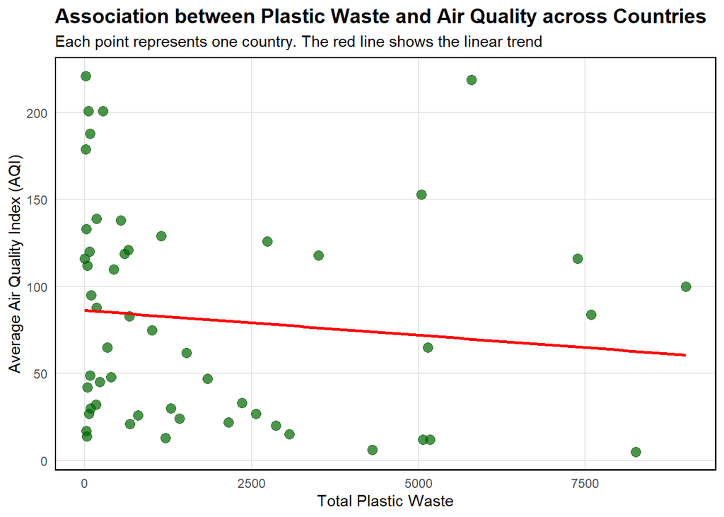

```r
windowsFonts(Arial = windowsFont("Arial"))

Q1 <- quantile(air_vs_plastic$total_plastic, 0.25)
Q3 <- quantile(air_vs_plastic$total_plastic, 0.75)
IQR <- Q3 - Q1

ggplot(data = air_vs_plastic |>
         filter(
           total_plastic >= Q1 - 1.5 * IQR,
           total_plastic <= Q3 + 1.5 * IQR),
       aes(x = total_plastic, y = avg_aqi)
       ) +
  geom_point(aes(color = avg_aqi), size = 3, alpha = 0.7, color = "darkgreen") +
  geom_smooth(method = "lm", se = FALSE, color = "red") +
  labs(
    title = "Association between Plastic Waste and Air Quality across Countries",
    subtitle = "Each point represents one country. The red line shows the linear trend",
    x = "Total Plastic Waste",
    y = "Average Air Quality Index (AQI)",
    alt = "Scatter plot showing the relationship between total plastic waste and average air quality index    across countries. Each point represents a country. A red linear trend line slopes slightly downward, showing  a weak negative relationship between plastic waste and air quality."
  ) +
  theme_minimal() +
  theme(
    text = element_text(family = "Arial"),
    plot.title = element_text(face = "bold", size = 14),
    plot.subtitle = element_text(colour = "black", size = 11),
    panel.grid.minor = element_blank(),
    panel.grid.major = element_line(color = "gray90"),
    panel.border = element_rect(color = "black", fill = NA, linewidth = 0.8),
  )
```

Notes: This scatter plot shows the relationship between total plastic waste and average AQI for each country, with outliers removed. Each green point is one country, and the red line shows the overall linear trend. The trend line slopes slightly downward, indicating a weak negative relationship between plastic waste and air quality. Countries with more plastic waste tend to have slightly lower AQI scores, meaning slightly better air quality. However, the points are scattered widely around the line, meaning this pattern is inconsistent across countries and plastic waste alone does not strongly predict air quality.

Table 5: table shows the results of a linear regression model predicting average AQI from total plastic waste across countries

```r
model <- lm(avg_aqi ~ total_plastic, data = air_vs_plastic)
summary_model <- summary(model)

r_squared <- round(summary_model$r.squared, 4)
adj_r_squared <- round(summary_model$adj.r.squared, 4)
f_stat <- round(summary_model$fstatistic[1], 3)
p_value_model <- round(pf(summary_model$fstatistic[1],
                          summary_model$fstatistic[2],
                          summary_model$fstatistic[3],
                          lower.tail = FALSE), 4)

data.frame(
  Term = c("Intercept", "Total Plastic"),
  Estimate = coef(model),
  Standard_Error = summary_model$coefficients[, 2],
  T_Statistic = summary_model$coefficients[, 3],
  P_Value = summary_model$coefficients[, 4]
) |>
  gt() |>
  opt_table_font(font = "Arial") |>
  tab_header(
    title = "Linear Regression Results",
    subtitle = "Predicting Average AQI from Total Plastic Waste by Country"
  ) |>
  tab_spanner(
    label = "Coefficient Information",
    columns = c(Estimate, Standard_Error)
  ) |>
  tab_spanner(
    label = "Test Statistics",
    columns = c(T_Statistic, P_Value)
  ) |>
  cols_label(
    Term = "Term",
    Estimate = "Estimate",
    Standard_Error = "Standard Error",
    T_Statistic = "T-Statistic",
    P_Value = "P-Value"
  ) |>
  tab_style(
    style = cell_text(weight = "bold"),
    locations = cells_column_labels()
  ) |>
  fmt_number(columns = c(Estimate, Standard_Error, T_Statistic), decimals = 3) |>
  fmt_number(columns = P_Value, decimals = 4) |>
  tab_source_note(glue::glue("R² = {r_squared} | Adjusted R² = {adj_r_squared} | F-statistic = {f_stat} | Model p-value = {p_value_model}"))
```

Linear Regression Results

Predicting Average AQI from Total Plastic Waste by Country

| Term | Coefficient Information Estimate | Coefficient Information Standard Error | Test Statistics T-Statistic | Test Statistics P-Value |
| --- | --- | --- | --- | --- |
| Intercept | 77.593 | 8.957 | 8.662 | 0.0000 |
| Total Plastic | 0.001 | 0.001 | 0.957 | 0.3429 |

R² = 0.0161 | Adjusted R² = -0.0015 | F-statistic = 0.915 | Model p-value = 0.3429